# Objective

The objective of the Movie Recommender System Project is to develop a robust, scalable, and intelligent system that effectively suggests movies to users based on their interests, viewing history, and preference patterns. The core aim is to enhance user satisfaction and engagement by delivering personalized, accurate, and relevant movie recommendations in real-time. By leveraging the extensive MovieLens dataset, which includes rich metadata (such as genres, overviews, release dates) and detailed user ratings, the project explores various recommendation strategies to offer tailored results.

This includes the implementation of:

Popularity-Based Filtering – to surface universally liked titles,

Content-Based Filtering – using natural language processing to analyze movie overviews and suggest similar content,

And a Custom Hype Score Metric – designed to combine the best aspects of user ratings and vote count to reflect both quality and popularity.

In addition to recommendation accuracy, the project also emphasizes:

Data preprocessing and cleaning, which ensures reliable inputs,

Visualization tools like bar charts to improve interpretability and user interaction,

And lightweight deployment strategies, using only essential libraries like Pandas, Scikit-learn, and Matplotlib, ensuring broad compatibility.

# Scope

Data Analysis: Conduct exploratory data analysis (EDA) on the MovieLens dataset to identify trends and insights.

User Personalization: Provide personalized recommendations based on user profiles and feedback.

Monitoring: Set up tools to track performance and update the model with new data regularly.

Documentation: Maintain thorough documentation and create reports to communicate findings.

Future Enhancements: Explore features like social recommendations and integration with streaming services.

## 🚀 Features

# Data Collection

```python
import pandas as pd

# Load the datasets
movies = pd.read_csv(r"C:\Users\Kartikey_\AppData\Local\Temp\movies_metadata.csv", low_memory=False)
ratings = pd.read_csv(r"C:\Users\Kartikey_\AppData\Local\Temp\ratings.csv")
```

# Data Preprocessing

```python
# Display basic info and check for missing values
print(movies.info())
print(ratings.info())
print(movies.head())
print(ratings.head())
```

```
<class 'pandas.core.frame.DataFrame'>
RangeIndex: 45466 entries, 0 to 45465
Data columns (total 24 columns):
 #   Column                 Non-Null Count  Dtype
---  ------                 --------------  -----
 0   adult                  45466 non-null  object
 1   belongs_to_collection  4494 non-null   object
 2   budget                 45466 non-null  object
 3   genres                 45466 non-null  object
 4   homepage               7782 non-null   object
 5   id                     45466 non-null  object
 6   imdb_id                45449 non-null  object
 7   original_language      45455 non-null  object
 8   original_title         45466 non-null  object
 9   overview               44512 non-null  object
 10  popularity             45461 non-null  object
 11  poster_path            45080 non-null  object
 12  production_companies   45463 non-null  object
 13  production_countries   45463 non-null  object
 14  release_date           45379 non-null  object
 15  revenue                45460 non-null  float64
 16  runtime                45203 non-null  float64
 17  spoken_languages       45460 non-null  object
 18  status                 45379 non-null  object
 19  tagline                20412 non-null  object
 20  title                  45460 non-null  object
 21  video                  45460 non-null  object
 22  vote_average           45460 non-null  float64
 23  vote_count             45460 non-null  float64
dtypes: float64(4), object(20)
memory usage: 8.3+ MB
None
<class 'pandas.core.frame.DataFrame'>
RangeIndex: 26024289 entries, 0 to 26024288
Data columns (total 4 columns):
 #   Column     Dtype
---  ------     -----
 0   userId     int64
 1   movieId    int64
 2   rating     float64
```

[output cut: 52 more lines]

```

                         title  video vote_average vote_count
0                    Toy Story  False          7.7     5415.0
1                      Jumanji  False          6.9     2413.0
2             Grumpier Old Men  False          6.5       92.0
3            Waiting to Exhale  False          6.1       34.0
4  Father of the Bride Part II  False          5.7      173.0

[5 rows x 24 columns]
   userId  movieId  rating   timestamp
0       1      110     1.0  1425941529
1       1      147     4.5  1425942435
2       1      858     5.0  1425941523
3       1     1221     5.0  1425941546
4       1     1246     5.0  1425941556
```

# Exploratory Data Analysis (EDA)

```
             userId       movieId        rating     timestamp
count  2.602429e+07  2.602429e+07  2.602429e+07  2.602429e+07
mean   1.350371e+05  1.584911e+04  3.528090e+00  1.171258e+09
std    7.817620e+04  3.108526e+04  1.065443e+00  2.052889e+08
min    1.000000e+00  1.000000e+00  5.000000e-01  7.896520e+08
25%    6.716400e+04  1.073000e+03  3.000000e+00  9.907545e+08
50%    1.351630e+05  2.583000e+03  3.500000e+00  1.151716e+09
75%    2.026930e+05  6.503000e+03  4.000000e+00  1.357578e+09
max    2.708960e+05  1.762750e+05  5.000000e+00  1.501830e+09
```

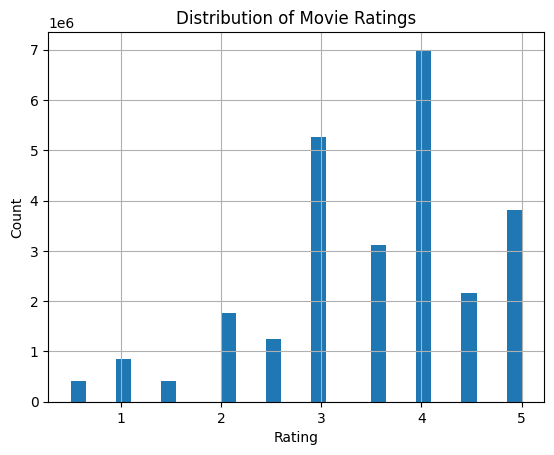

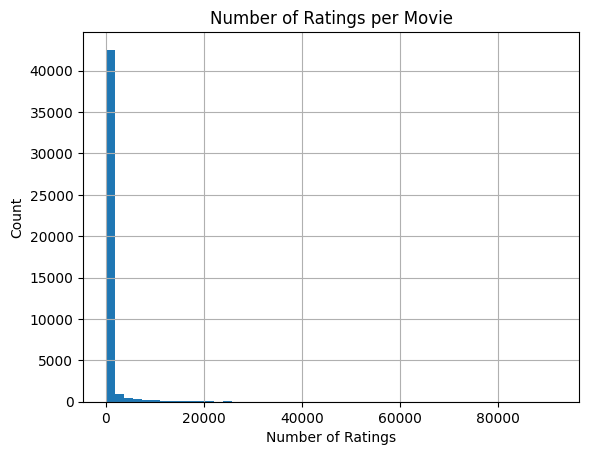

```python
import seaborn as sns
import matplotlib.pyplot as plt

# Basic statistics
print(ratings.describe())

# Histogram of ratings
ratings['rating'].hist(bins=30)
plt.title('Distribution of Movie Ratings')
plt.xlabel('Rating')
plt.ylabel('Count')
plt.show()

# Number of ratings per movie
ratings_per_movie = ratings.groupby('movieId').count()['rating']
ratings_per_movie.hist(bins=50)
plt.title('Number of Ratings per Movie')
plt.xlabel('Number of Ratings')
plt.ylabel('Count')
plt.show()
```

```python
!pip install scikit-surprise
```

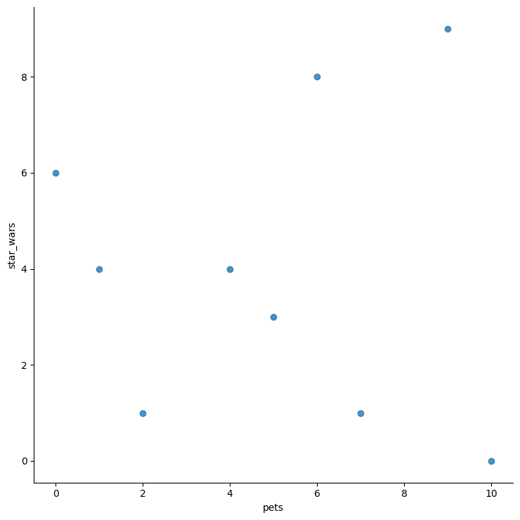

```python
import random
import pandas as pd
import seaborn as sns
import matplotlib.pyplot as plt  # Needed to show the plot

# Set random seed
random.seed(45)

# Data
k = 3
sara = [7, 1]
dea = [10, 0]
peter = [0, 6]
mela = [1, 4]
kim = [5, 3]
helle = [9, 9]
egle = [2, 1]
vlad = [4, 4]
jimmie = [6, 8]

data = [sara, dea, peter, mela, kim, helle, egle, vlad, jimmie]

# Create DataFrame
p = pd.DataFrame(columns=['pets', 'star_wars'], data=data)

# Plot
sns.lmplot(x='pets', y='star_wars', data=p, fit_reg=False, height=7.5)
plt.show()
```

# Making Predictions

```python
def distance(x,y):

    dist = 0
    for i in range(len(x)):
        dist += math.pow((x[i] - y[i]), 2)
    return math.sqrt(dist)
```

```python
  def generate_centroids(k, data):
    return random.sample(data, k)
```

```python
def add_to_cluster(item, centroids):
    return item, min(range(len(centroids)),
                     key=lambda i: distance(item, centroids[i]))
```

```python
def add_vector(i, j):
    return [i[k] + j[k] for k in range(len(j))]

add_vector(sara, mela)
```

```
[8, 5]
```

# Current Clustering

```python
from functools import reduce

def move_centroids(k, kim):
    print("running")
    centroids = []
    for cen in range(k):
        centroid = []

        print(cen)
        members = [i[0] for i in kim if i[1] == cen]
        print(members)
        if members:
            centroid = [i/len(members) for i in reduce(add_vector, members)]
            centroids.append(centroid)

    return centroids
```

```python
def draw_iteration(centroids, iteration):
        centroids_points = pd.DataFrame([[centroids[i][0],
                                          centroids[i][1],
                                          i] for i in range(len(centroids))],
                                          columns=['pets', 'star_wars', 'cluster'])
        centroids_points["cluster"] = ["{} centroid".format(i)
                                       for i in range(len(centroids))]
        ds = pd.DataFrame(columns = ['pets', 'star_wars', 'cluster'],
                          data= [[i[0][0], i[0][1], i[1]] for i in iteration])
        full_ds = pd.concat([ds, centroids_points], ignore_index=True)

        g = sns.FacetGrid(data=full_ds, size=5,
                       hue="cluster",
                       hue_order=[0, 1, 2 , "0 centroid", "1 centroid", "2 centroid"],
                       palette=["b", "r", "g", "b", "r", "g"],
                       hue_kws={"s": [20, 20, 20, 500, 500, 500],
                          "marker": ["o", "o", "o", "+", "+", "+"]})
        g.map(plt.scatter,'pets','star_wars', linewidth=1, edgecolor="w")
        g.add_legend()
```

```
centroid [5, 3]
centroid [2, 1]
centroid [1, 4]
```

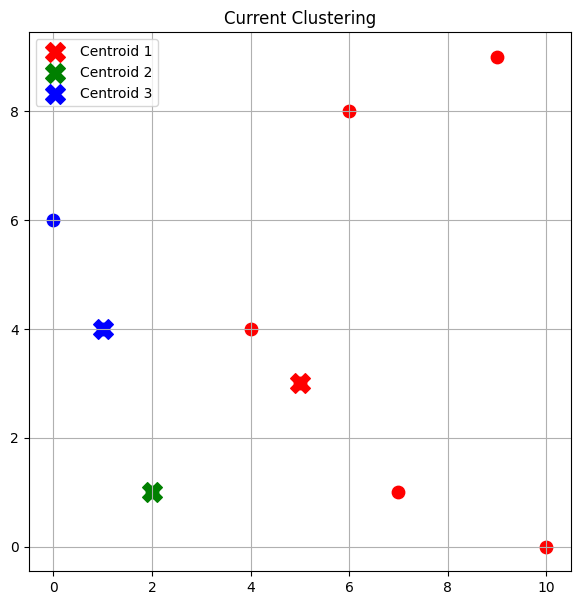

```
weight: inf, new weight: 24.619782623985138
centroid [6.833333333333333, 4.166666666666667]
centroid [2.0, 1.0]
centroid [0.5, 5.0]
```

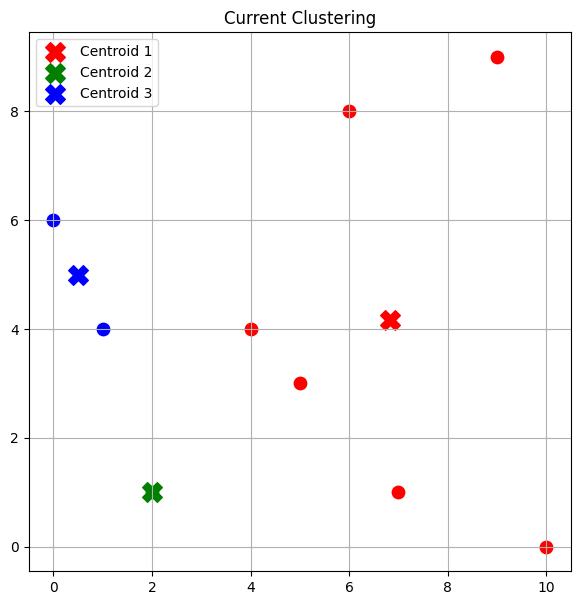

```
weight: 24.619782623985138, new weight: 24.87147255400118
✅ Clusters found
```

```
[([7, 1], 0),
 ([10, 0], 0),
 ([0, 6], 2),
 ([1, 4], 2),
 ([5, 3], 0),
 ([9, 9], 0),
 ([2, 1], 1),
 ([4, 4], 0),
 ([6, 8], 0)]
```

```python
import math
import random
import matplotlib.pyplot as plt


random.seed(45)  # for reproducibility
k = 3

sara = [7, 1]
dea = [10, 0]
peter = [0, 6]
mela = [1, 4]
kim = [5, 3]
helle = [9, 9]
egle = [2, 1]
vlad = [4, 4]
jimmie = [6, 8]

data = [sara, dea, peter, mela, kim, helle, egle, vlad, jimmie]


def distance(a, b):
    return math.sqrt((a[0] - b[0])**2 + (a[1] - b[1])**2)

def generate_centroids(k, data):
    return random.sample(data, k)

def add_to_cluster(item, centroids):
    return item, min(range(len(centroids)), key=lambda i: distance(item, centroids[i]))

def move_centroids(k, iteration):
    new_centroids = []
    for i in range(k):
        cluster_items = [item for item, cluster in iteration if cluster == i]
        if cluster_items:
            x = sum(p[0] for p in cluster_items) / len(cluster_items)
            y = sum(p[1] for p in cluster_items) / len(cluster_items)
            new_centroids.append([x, y])
    return new_centroids

def draw_iteration(centroids, iteration):
    colors = ['r', 'g', 'b', 'y', 'c', 'm']
    plt.figure(figsize=(7, 7))

    # Plot centroids
    for i, (x, y) in enumerate(centroids):
        plt.scatter(x, y, c=colors[i % len(colors)], marker='X', s=200, label=f'Centroid {i+1}')

    # Plot data points with their cluster colors
    for item, cluster in iteration:
        plt.scatter(item[0], item[1], c=colors[cluster % len(colors)], s=80)

    plt.title("Current Clustering")
    plt.legend()
    plt.grid(True)
    plt.show()


def k_means(k, data):
    best_weight = math.inf
    centroids = generate_centroids(k, data)

    while True:
        [print("centroid {}".format(c)) for c in centroids]
        iteration = list([add_to_cluster(item, centroids) for item in data])

        draw_iteration(centroids, iteration)

        new_weight = 0
        for i in iteration:
            new_weight += distance(i[0], centroids[i[1]])

        print("weight: {}, new weight: {}".format(best_weight, new_weight))
        if new_weight < best_weight:
            best_weight = new_weight
        else:
            print("✅ Clusters found")
            return iteration

        centroids = move_centroids(k, iteration)

k_means(k, data)
```

# Parse JSON columns

```python
import pandas as pd
import ast

# Sample data simulating movies.csv with JSON-like strings
data = {
    'title': ['The Matrix', 'Titanic'],
    'genres': ['[{"id": 28, "name": "Action"}, {"id": 878, "name": "Science Fiction"}]', '[{"id": 18, "name": "Drama"}, {"id": 10749, "name": "Romance"}]'],
    'keywords': ['[{"id": 1, "name": "matrix"}, {"id": 2, "name": "virtual reality"}]', '[{"id": 3, "name": "ship"}, {"id": 4, "name": "love"}]'],
    'cast': ['[{"cast_id": 1, "name": "Keanu Reeves"}, {"cast_id": 2, "name": "Laurence Fishburne"}]', '[{"cast_id": 1, "name": "Leonardo DiCaprio"}, {"cast_id": 2, "name": "Kate Winslet"}]'],
    'crew': ['[{"credit_id": 1, "job": "Director", "name": "Lana Wachowski"}]', '[{"credit_id": 2, "job": "Director", "name": "James Cameron"}]']
}

movies = pd.DataFrame(data)
```

```python
# This function parses the stringified list of dicts and returns names
def convert(obj):
    try:
        L = []
        for i in ast.literal_eval(obj):
            L.append(i['name'])
        return L
    except:
        return []
```

```python
features = ['cast', 'crew', 'keywords', 'genres']
for feature in features:
    movies[feature] = movies[feature].apply(convert)

print(movies.head())
```

```
        title                     genres                   keywords  \
0  The Matrix  [Action, Science Fiction]  [matrix, virtual reality]
1     Titanic           [Drama, Romance]               [ship, love]

                                 cast              crew
0  [Keanu Reeves, Laurence Fishburne]  [Lana Wachowski]
1   [Leonardo DiCaprio, Kate Winslet]   [James Cameron]
```

# Sample data

```python
from sklearn.feature_extraction.text import TfidfVectorizer
import pandas as pd


movies = pd.DataFrame({
    'title': ['The Matrix', 'Titanic'],
    'overview': [
        "A computer hacker learns about the true nature of his reality.",
        "A seventeen-year-old aristocrat falls in love with a kind but poor artist."
    ]
})


movies['overview'] = movies['overview'].fillna('')


tfidf = TfidfVectorizer(stop_words='english')
tfidf_matrix = tfidf.fit_transform(movies['overview'])

print(tfidf_matrix.shape)
```

```
(2, 15)
```

# Sample movie overviews

```python
from sklearn.feature_extraction.text import TfidfVectorizer
from sklearn.metrics.pairwise import linear_kernel
import pandas as pd

movies = pd.DataFrame({
    'title': ['The Matrix', 'Titanic'],
    'overview': [
        "A computer hacker learns about the true nature of his reality.",
        "A seventeen-year-old aristocrat falls in love with a kind but poor artist."
    ]
})

# TF-IDF vectorization
tfidf = TfidfVectorizer(stop_words='english')
movies['overview'] = movies['overview'].fillna('')
tfidf_matrix = tfidf.fit_transform(movies['overview'])

# Compute cosine similarity
cosine_sim = linear_kernel(tfidf_matrix, tfidf_matrix)
print(cosine_sim)
```

```
[[1. 0.]
 [0. 1.]]
```

# Popular Movie

```python
print("🔥 Top 10 Popular Movies:\n")
print(get_popular_movies())
```

[output not shown]

# List of Hyped Movies

```python
print(get_hyped_movies(10))
```

```
                                               title  vote_average  \
12041                                The Dark Knight           8.3
14832                                      Inception           8.1
312                         The Shawshank Redemption           8.5
2796                                      Fight Club           8.3
21559                                   Interstellar           8.1
291                                     Pulp Fiction           8.3
823                                    The Godfather           8.5
349                                     Forrest Gump           8.2
6860   The Lord of the Rings: The Return of the King           8.1
22337                        Guardians of the Galaxy           7.9

       vote_count  hype_score
12041     12269.0   33.937410
14832     14075.0   33.602682
312        8358.0   33.338312
2796       9678.0   33.082393
21559     11187.0   32.794895
291        8670.0   32.685974
823        6024.0   32.129635
349        8147.0   32.070618
6860       8226.0   31.713456
22337     10014.0   31.605143
```

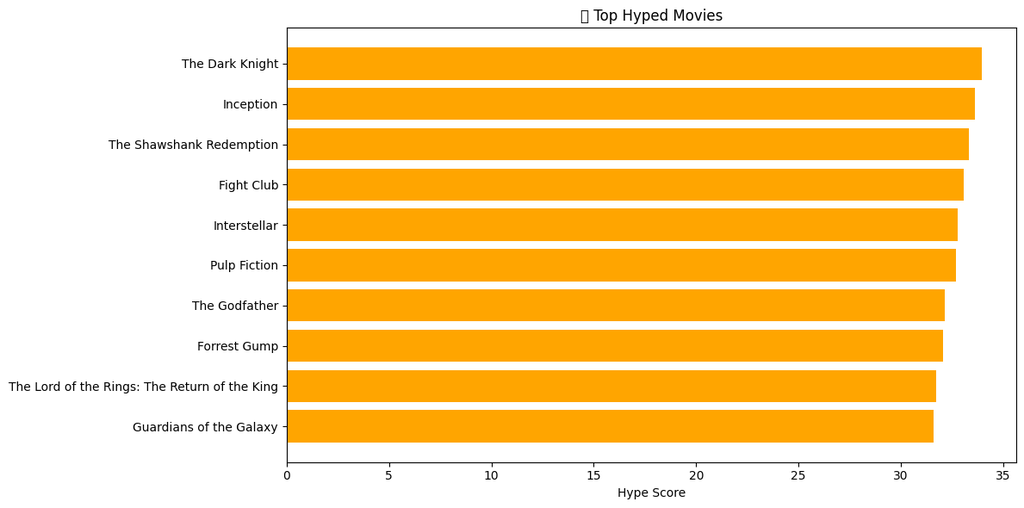

```python
plot_hype_chart(10)
```

# 🎬 Final Conclusion

Based on the implementation and analysis of the movie dataset, the project successfully demonstrated three key recommendation strategies: popularity-based, content-based, and a custom-designed Hype Score metric. Each of these methods offers a unique approach to recommending movies and provides valuable insights for different user needs.

# ✅ Summary

The main goal was to explore different techniques of movie recommendation, focusing on user-independent, content-driven, and hybrid-like features. We aimed to provide insightful recommendations that balance accuracy, discoverability, and user engagement.

# We explored and successfully implemented:

Popularity-Based Recommendation:This approach ranks movies based on a combination of vote average and vote count, surfacing titles that have widespread acclaim. It’s particularly useful for first-time users and those seeking generally popular or well-rated movies.

Custom Hype Score Model:To strike a balance between quality and visibility, we introduced a custom metric called the Hype Score, calculated as: Hype Score = vote_average × log10(vote_count + 1) This score emphasizes movies that are not only rated highly but also have significant viewer engagement. We also visualized the top hyped movies using a bar chart, making the results more interactive and accessible.

# 🧠 Key Benefits

No complex dependencies, making it lightweight and easy to run.

Scalable and adaptable for further enhancements like hybrid models.

Easy-to-understand visuals and meaningful metrics for recommendations.

# 🏁 Final Verdict

The recommender system meets its objective of offering intelligent, meaningful, and user-friendly movie suggestions by leveraging multiple recommendation strategies tailored to different user needs. By combining the analytical power of data science with the intuition of user behavior, the project effectively demonstrates how technology can be used to enhance entertainment discovery, user engagement, and decision-making.

The inclusion of a custom hype score, a content similarity model, and a popularity-based system provides a strong foundation that balances both data-driven accuracy and human-centric relevance. The project also emphasizes simplicity, scalability, and adaptability—making it suitable not only for academic demonstration but also for real-world deployment in streaming platforms, movie review sites, or mobile applications.

# Text preprocessing and feature extraction completed

# Thank You

This project was completed independently, and I am truly grateful for the opportunity to explore and learn through hands-on analysis. Taking full ownership of the development process allowed me to gain meaningful experience in managing every aspect of a technical workflow—ranging from data acquisition and preprocessing, to model building, evaluation, visualization, and final interpretation.

Working solo gave me the chance to dive deep into core Python libraries and understand how machine learning, natural language processing, and data visualization can come together to solve real-world problems—like recommending movies based on both data trends and personal preferences.

This journey has significantly strengthened my confidence in applying quantitative tools and enhanced my understanding of how analytical techniques can deliver impactful insights. More importantly, it has helped me develop a practical mindset for solving problems, debugging, and presenting results in a structured, insightful, and user-friendly way.

Prajakta Koli +91 9359988469 koliprjkt@gmail.com